# Data Minning Assessment- Amazon Books Review

# Exploratory Data Analysis

```r
df %>% group_by(Genre) %>% summarise(count=n()) %>% arrange(desc(count))->genre_counts
head(genre_counts) # Top 6 Genre with a lot of count of books
```

```
## # A tibble: 6 × 2
##   Genre                     count
##   <chr>                     <int>
## 1 Fiction                   12663
## 2 Religion                   4266
## 3 Juvenile Fiction           3190
## 4 Biography & Autobiography  3094
## 5 History                    3018
## 6 Business & Economics       2930
```

# Viewing plot for the Top 10 Genres

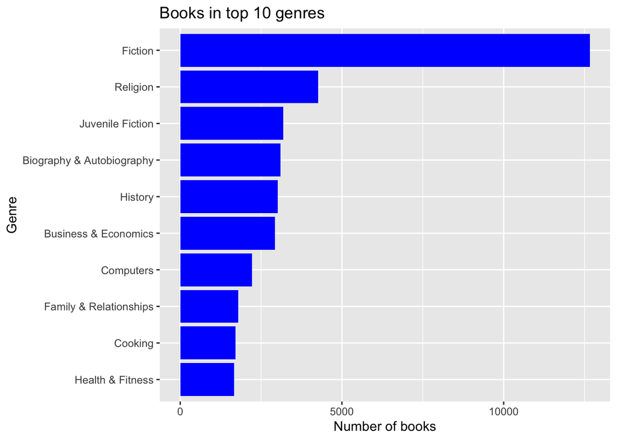

```r
genre_counts$Genre <- reorder(genre_counts$Genre,genre_counts$count)
top_10 <- head(genre_counts,10)

ggplot(top_10)+
  geom_col(aes(y = Genre, x=count),fill='blue')+
  labs(x = "Number of books",title = "Books in top 10 genres")
```

# Finding Minimum, Maximum and Average No. of Reviews

```r
summary(genre_counts)
```

```
##                       Genre        count
##  Authors, English        : 1   Min.   :    1.0
##  Brothers and sisters    : 1   1st Qu.:    8.0
##  Comic books, strips, etc: 1   Median :  225.0
##  English poetry          : 1   Mean   :  697.6
##  Indians of North America: 1   3rd Qu.:  741.0
##  Science fiction         : 1   Max.   :12663.0
##  (Other)                 :79
```

# Data Sampling

```r
set.seed(20)

# Filtering genres with more than 80 books
Genre_sample = filter(genre_counts,count >= 80)

# 6 random sample index
sample_index <- sample(length(unique(Genre_sample$Genre)), 6)

#Selecting genres to use for analysis
sampled_genre <- unique(Genre_sample$Genre)[sample_index]
df <- df %>% filter(Genre %in% sampled_genre)
df <- df %>% group_by(Genre) %>% slice_sample(n=100)

#ungrouping to remove groups
df <- ungroup(df)


print(summary(df))
```

```
##     Title               Rating      Review_title       Review_text
##  Length:600         Min.   :1.000   Length:600         Length:600
##  Class :character   1st Qu.:4.000   Class :character   Class :character
##  Mode  :character   Median :5.000   Mode  :character   Mode  :character
##                     Mean   :4.263
##                     3rd Qu.:5.000
##                     Max.   :5.000
##     Genre           Review_id_new
##  Length:600         Min.   :   43
##  Class :character   1st Qu.:15004
##  Mode  :character   Median :29589
##                     Mean   :29741
##                     3rd Qu.:45224
##                     Max.   :59175
```

In the process of tidying up the text reviews, tokenization was employed to segment the text into smaller components, thereby distinguishing punctuation and special characters from individual words. Both word tokenization and n-gram tokenization were employed as methods in this investigation.

# Tokenization

```r
#Tokenization the Review text column by words
word_tokenized_data <- df %>%
  unnest_tokens(output = word, input = "Review_text", token = "words", to_lower = TRUE)

#Tokenization of the Review text column into bi-grams
bigram_tokenized_data <- df %>%
  unnest_tokens(output = bigram, input = "Review_text", token = "ngrams", n=2, to_lower = TRUE)
```

# Initial Word plot

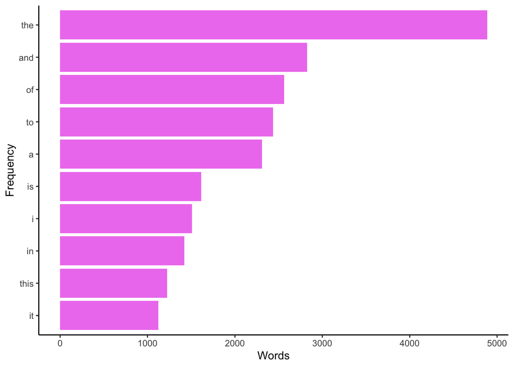

```r
#Plotting top 10 words sorted by tokenized data
word_counts <- word_tokenized_data %>%
  count(word, sort = TRUE)

ggplot(word_counts[1:10, ], aes(y = reorder(word, n), x = n)) +
  geom_col(fill='violet') +
  labs(x = "Words", y = "Frequency") +
  theme_classic()
```

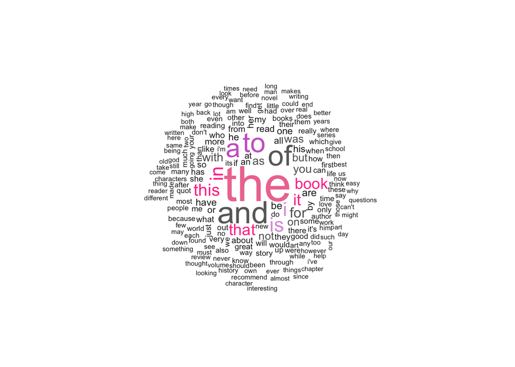

```r
set.seed(20)
wordcloud(words = word_counts$word, freq = word_counts$n, min.freq = 50, random.order=FALSE, random.color=FALSE, colors = sample(colors(), size = 10))
```

# Initial Bigram

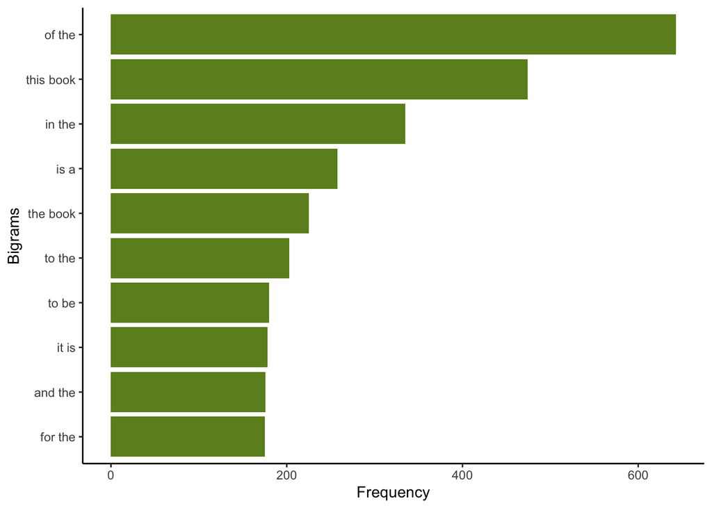

```r
bigram_counts <- bigram_tokenized_data %>%
  count(bigram, sort = TRUE)

ggplot(bigram_counts[1:10, ], aes(x = reorder(bigram, n), y = n)) +
  geom_col(fill = "olivedrab") +
  labs(x = "Bigrams", y = "Frequency") +
  coord_flip() +
  theme_classic()
```

# Cleaning Data

```r
#Removing stop words
tokens_cleaned <- word_tokenized_data %>%
  anti_join(stop_words, by = "word")

#Removing  special characters and numbers and replacing empty strings with NA so as to lemmatize the text.
tokens_cleaned$word <- gsub("[^a-zA-Z ]", "", tokens_cleaned$word) %>%
  na_if("") %>%
  lemmatize_words()
tokens_cleaned <- na.omit(tokens_cleaned)
```

```r
#Joining the cleaned tokens to the original dataset (df)
untokenized_data <- tokens_cleaned %>%
  group_by(Review_id_new) %>%
  summarize(clean_review = paste(word, collapse = " ")) %>%
  inner_join(df[,-4], by="Review_id_new")

#Creating n-grams of the clean review column (bi-grams)
bigrams_cleaned <- untokenized_data %>%
  unnest_tokens(output = bigram, input = "clean_review", token = "ngrams", n=2, to_lower = TRUE)
```

A Plot created for the 10 cleaned words to confirm words that are removed with bi-grams.

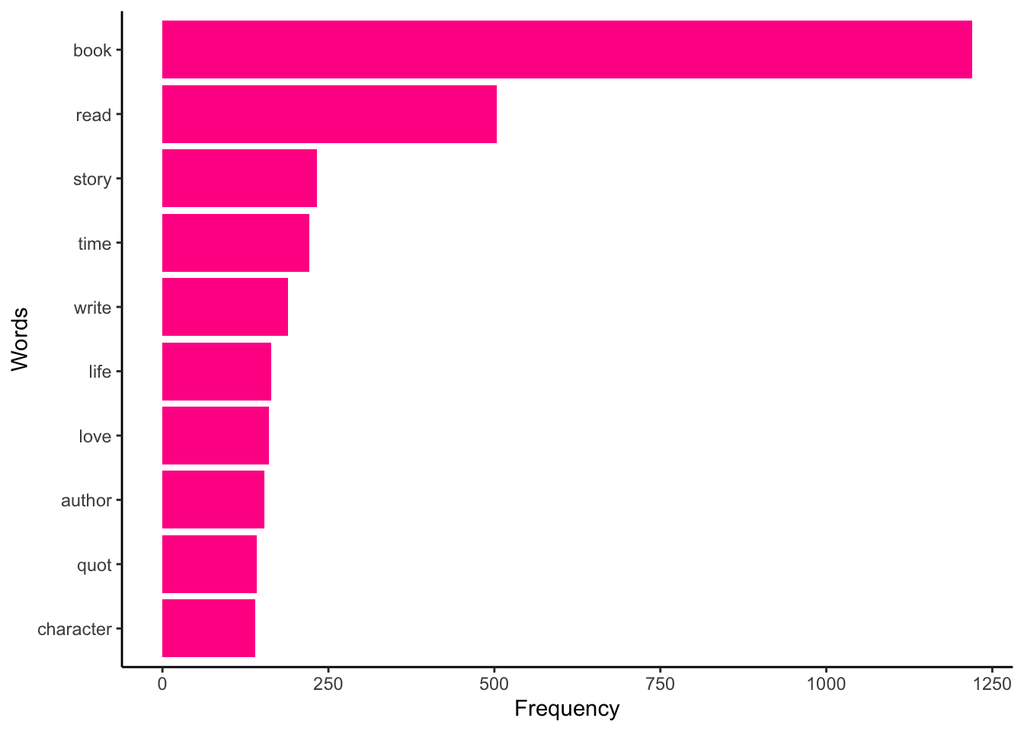

```r
#Creating a count of the cleaned tokens and sorting
word_counts <- tokens_cleaned %>%
  count(word, sort = TRUE)

#Top 10 words
top_words <- top_n(word_counts,10,n)$word
filtered_word_counts <- filter(word_counts, word %in% top_words)
filtered_word_counts$word <- factor(filtered_word_counts$word, levels = top_words[length(top_words):1])

#Plotting top 10 words
ggplot(filtered_word_counts, aes(x = reorder(word, n), y = n)) +
  geom_col(fill = "deeppink") +
  labs(x = "Words", y = "Frequency") +
  coord_flip() +
  theme_classic()
```

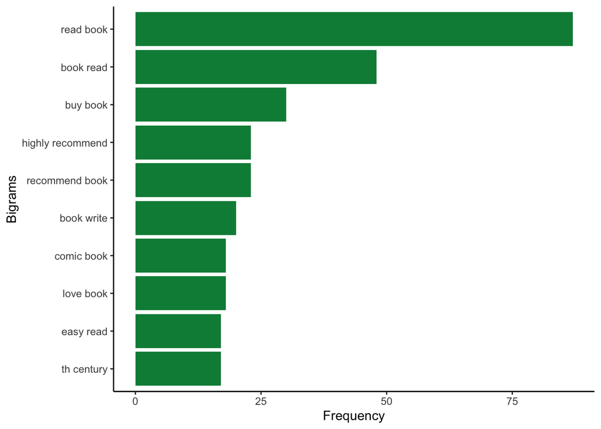

```r
#Creating bigrams counts and sorting
bigram_counts <- bigrams_cleaned %>%
  count(bigram, sort = TRUE)

#Top 10 bi-grams
top_bigrams <- top_n(bigram_counts,10,n)$bigram
filtered_bigram_counts <- filter(bigram_counts, bigram %in% top_bigrams)
filtered_bigram_counts$bigram <- factor(filtered_bigram_counts$bigram, levels = top_bigrams[length(top_bigrams):1])

#Plotting top 10 words
ggplot(filtered_bigram_counts, aes(x = reorder(bigram, n), y = n)) +
  geom_col(fill = "springgreen4") +
  labs(x = "Bigrams", y = "Frequency") +
  coord_flip() +
  theme_classic()
```

The plot above illustrates the exclusion of stop words, revealing that terms like “read,” “book,” and “write” emerging as prominent words in the review text in the dataset.

Additional exploration was made to view top words used in the 6 Genres selected for the analysis.

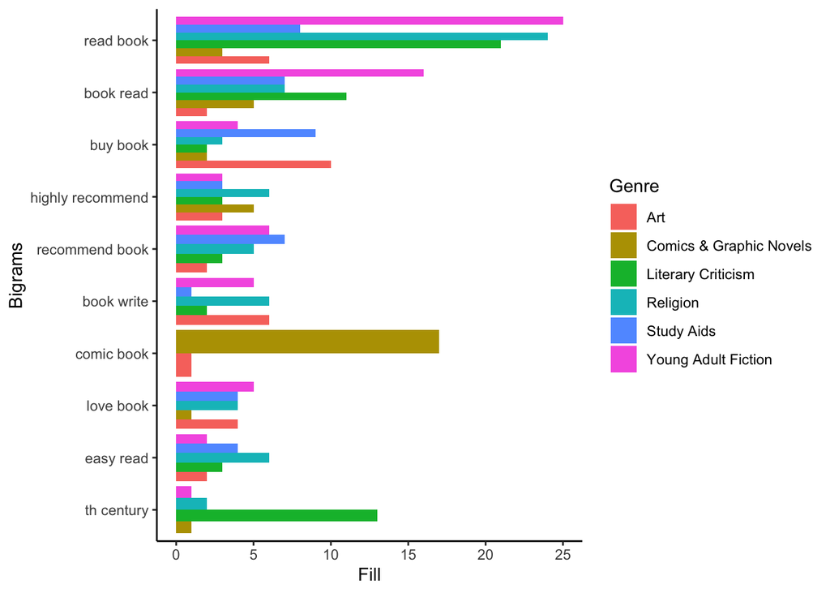

```r
#Top 10 bi-grams per genre
top_bigrams <- top_n(bigram_counts,10,n)$bigram

grouped_count <- group_by(bigrams_cleaned, Genre) %>%
  count(bigram) %>%
  filter(bigram %in% top_bigrams)

grouped_count$bigram <- factor(grouped_count$bigram, levels = top_bigrams[length(top_bigrams):1])

ggplot(data = grouped_count, aes(x = bigram, y = n, fill = Genre)) +
  geom_col(position = "dodge") +
  labs(x = "Bigrams", y = "Fill", fill = "Genre") +
  coord_flip() +
  theme_classic()
```

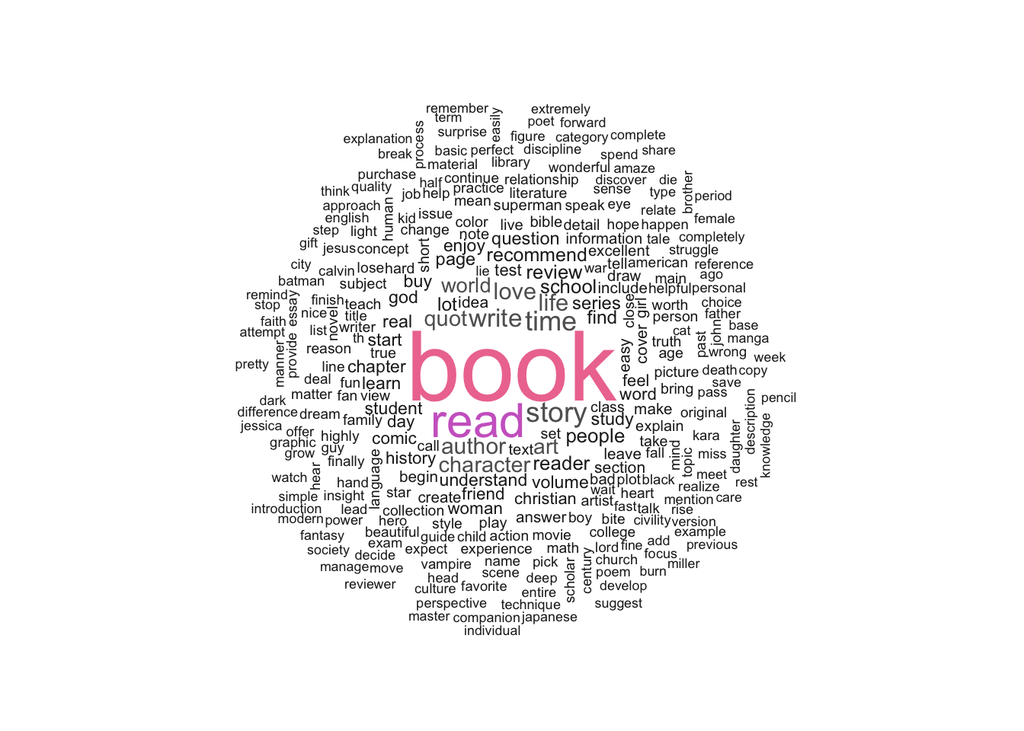

```r
set.seed(20)
wordcloud(words = word_counts$word, freq = word_counts$n, min.freq = 20, random.order=FALSE, random.color=FALSE, colors = sample(colors(), size = 10))
```

# TASK B

# BING Lexicons application

```r
#Joining the clean tokens with words present in bing dataset to form a new dataset.
sentiment_data <- tokens_cleaned %>%
  inner_join(get_sentiments("bing"), by = "word")


#Calculated Scores for each review
sentiment_score <- sentiment_data %>%
  group_by(Review_id_new) %>%
  summarize(bing_sentiment = sum(sentiment == "positive") - sum(sentiment == "negative"))

#Merging to compare scores with original df
df_sentiment = df %>%
  inner_join(sentiment_score, by = "Review_id_new")
```

# Below shows the review which was worst per the BING scores

```r
reviews_worst = df_sentiment[order(df_sentiment$bing_sentiment)[1],"Review_text"]

for (review in reviews_worst){
  print(review)
}
```

```
## [1] "\"Calvin and Hobbes\" really hit its stride with this volume. Here the laughter and poignancy hit meltdown levels. The title of the collection itself suggests carnage. And it delivers. So why didn't this incredible collection, including some of the strip's finest moments, never make it into …
```

# The review with the highest BING score is shown below:

```r
reviews_best = df_sentiment[order(df_sentiment$bing_sentiment, decreasing = TRUE)[1],"Review_text"]

for (review in reviews_best){
  print(review)
}
```

```
## [1] "The World of Suzie Wong is a fantasy, a lovely fairy tale written for adults; it is \"Cinderella\" as told by the Prince. Consider its plot: A poor but beautiful girl has always suspected she was really a princess, and after she has survived various ordeals, a chaste hero's kiss reveals the …
```

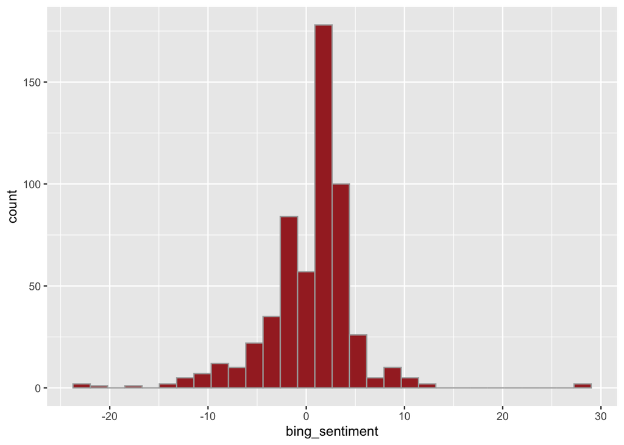

```r
# Histogram of sentiment scores
ggplot(df_sentiment, aes(x = bing_sentiment)) +
  geom_histogram(color='darkgray',fill='brown')
```

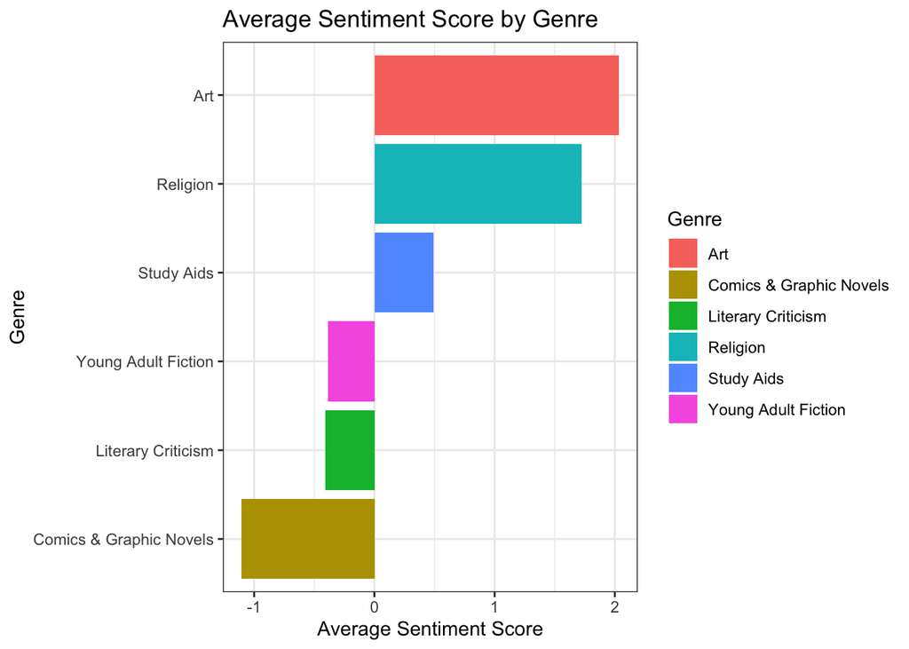

```r
# Mean sentiment scores by genre
sentiment_book <- df_sentiment %>%
  group_by(Genre) %>%
  summarize(avg_sentiment_score = mean(bing_sentiment))

ggplot(sentiment_book)+
  geom_bar(aes(x = reorder(Genre, avg_sentiment_score),
               y = avg_sentiment_score, fill = Genre),stat = "identity") +
  coord_flip() +
  labs(title = "Average Sentiment Score by Genre", x = "Genre",
       y = "Average Sentiment Score")+
  theme_bw()
```

The scores above confirms that “Art”, “Religion” and “Study Aids” had positive sentiments,since those are the only genres with positive average scores.

Distribution of Scores according to Genres

[figure not shown]

```r
ggplot(df_sentiment) +
  geom_boxplot(aes(y = bing_sentiment, x=Genre,group=Genre),fill='darkgoldenrod') +
  labs(title = " Box Plot - Bing sentiment score vs. Genre",
       y = "Scores",
       x = "Genre")
```

# Applying AFINN lexicon.

Each word in the AFINN lexicon is associated with a sentiment score ranging from -5 to +5 indicating emotional intensity or polarity. or emotional.

```r
#Joining the cleaned tokens with words present in AFINN lexicon to form new dataset
sentiment_data <- tokens_cleaned %>%
  inner_join(get_sentiments("afinn"), by = "word")

# scores are calculated for each review
sentiment_score <- sentiment_data %>%
  group_by(Review_id_new) %>%
  summarize(afinn_sentiment = sum(value))

# Merging with df
df_sentiment = df_sentiment %>%
  inner_join(sentiment_score, by = "Review_id_new")
```

# Below is the worst AFINN score:

```r
reviews_worst = df_sentiment[order(df_sentiment$afinn_sentiment)[1],"Review_text"]

for (review in reviews_worst){
  print(review)
}
```

```
## [1] "This book almost sounds like it was written by Michael Moore. I was forced to read this garbage for my softmore english class. Every aspect of this book can be connected to the anti-gun movement in the U.S. which targets their viewers with false information and half truths. The book actually…
```

# Below is the best AFINN score:

```r
reviews_best = df_sentiment[order(df_sentiment$afinn_sentiment, decreasing = TRUE)[1],"Review_text"]

for (review in reviews_best){
  print(review)
}
```

```
## [1] "The World of Suzie Wong is a fantasy, a lovely fairy tale written for adults; it is \"Cinderella\" as told by the Prince. Consider its plot: A poor but beautiful girl has always suspected she was really a princess, and after she has survived various ordeals, a chaste hero's kiss reveals the …
```

# Visualisations - AFINN

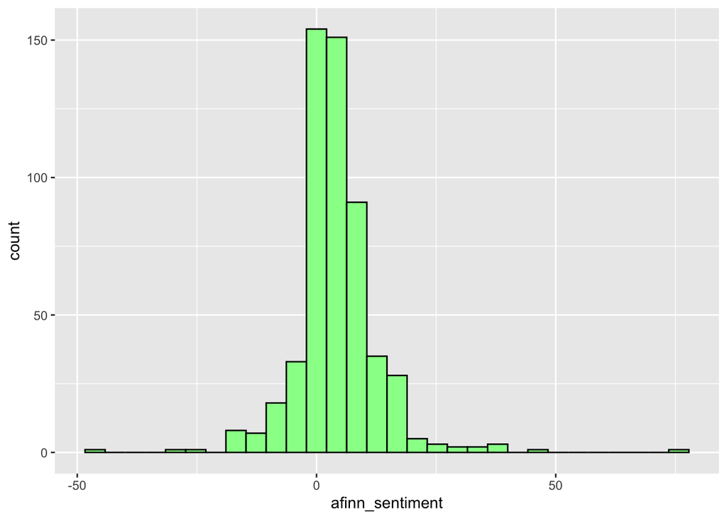

```r
# Histogram of sentiment scores
ggplot(df_sentiment, aes(x = afinn_sentiment)) +
  geom_histogram(color='black',fill='palegreen')
```

Majority of the scores were recorded between -38 to 38 with some few going beyond 50 and closer to -50.

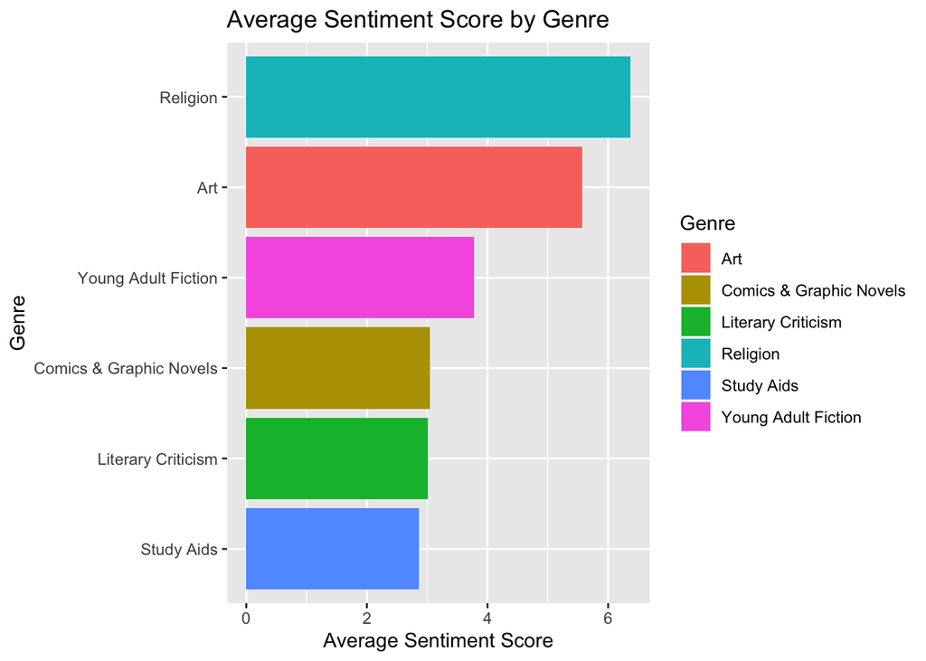

```r
# Mean Sentiment by Genre
genre_sentiment <- df_sentiment %>%
  group_by(Genre) %>%
  summarize(avg_afinn_sentiment = mean(afinn_sentiment))

ggplot(genre_sentiment, aes(x = reorder(Genre, avg_afinn_sentiment),
                             y = avg_afinn_sentiment, fill = Genre)) +
  geom_bar(stat = "identity") +
  coord_flip() +
  labs(title = "Average Sentiment Score by Genre", x = "Genre", y = "Average Sentiment Score")
```

From the above output, “Religion”, “Art” , “Young Adult Fiction” are the highest positive averages with “Comics & Graphics Novels” and “Literary Criticism” being slightly higher than “Study Aids”.

# Distribution of AFINN scores according to Genre

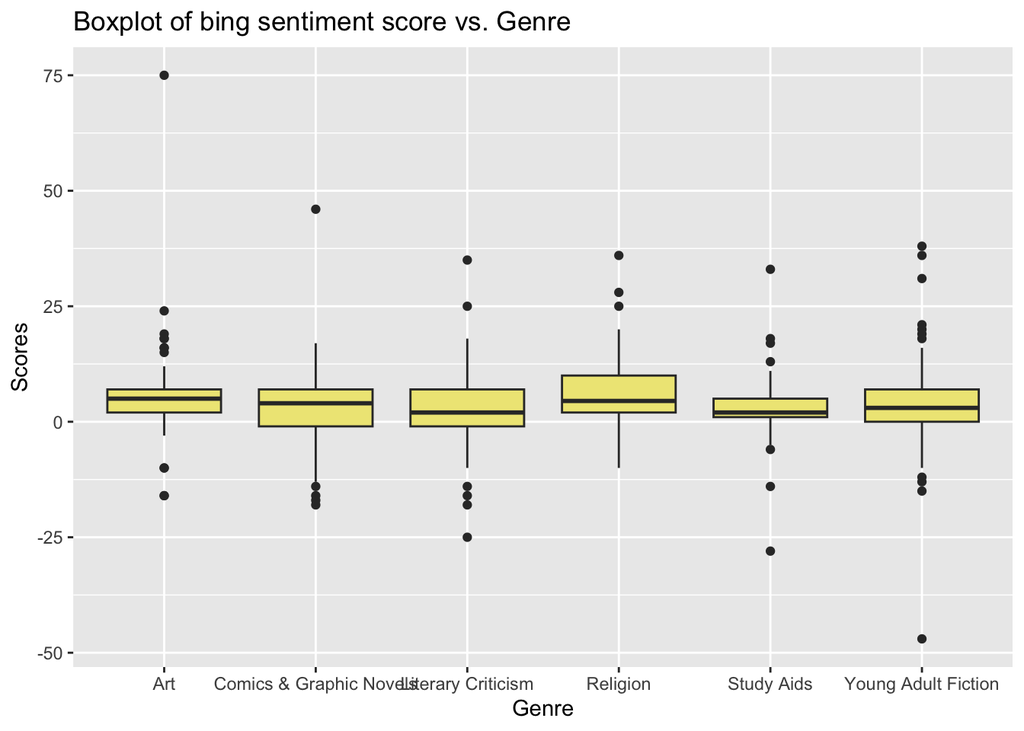

```r
ggplot(df_sentiment) +
  geom_boxplot(aes(y = afinn_sentiment, x=Genre,group=Genre),fill='khaki2') +
  labs(title = "Boxplot of bing sentiment score vs. Genre",
       y = "Scores",
       x = "Genre")
```

# Relationship between AFINN Scores and BING Scores

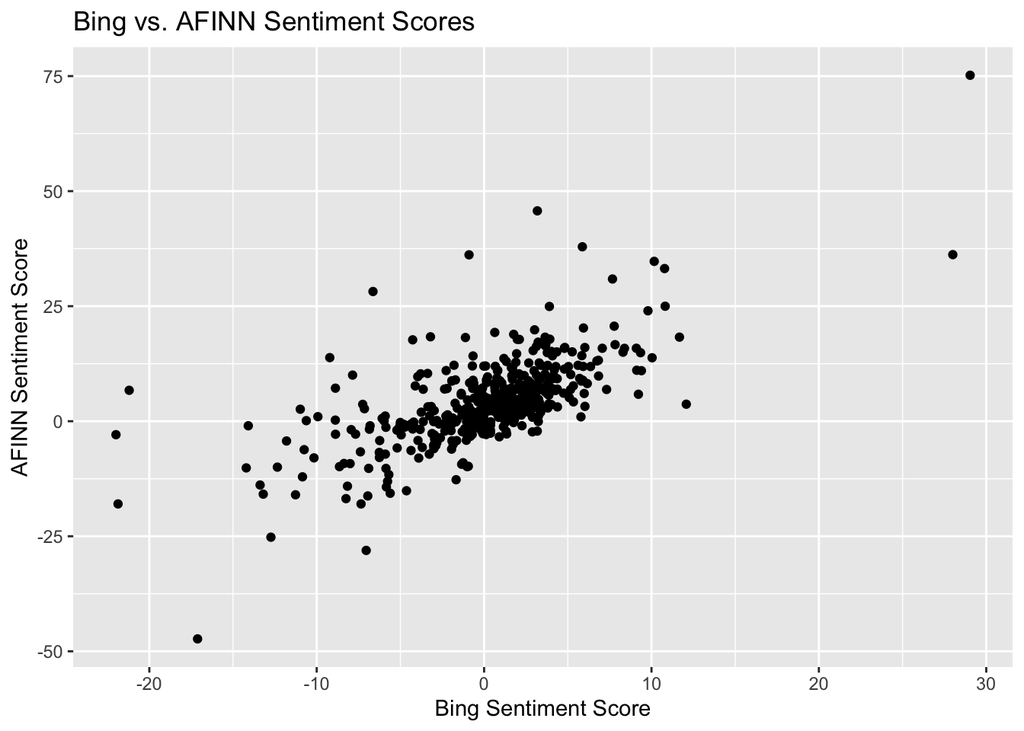

```r
ggplot(df_sentiment) +
  geom_jitter(aes(x = bing_sentiment,y = afinn_sentiment)) +
  labs(title = "Bing vs. AFINN Sentiment Scores",
       x = "Bing Sentiment Score",
       y = "AFINN Sentiment Score")
```

From the above plot, it can be explained that there is a positive relationship betweeen AFINN scores and BING scores.

# NRC LEXICONS

The NRC lexicon links words to eight fundamental emotions “disgust, joy, sadness, surprise, trust, anticipation, fear and anger”, as well as two sentiments: either positive or negative.

# Applying NRC

```r
#Joining the cleaned tokens with the NRC lexicon to form a new dataset
emotion_data <- tokens_cleaned %>%
  inner_join(get_sentiments("nrc"), by = "word")
# Each review sentiment's scores
emotion_count <- emotion_data %>%
  group_by(Review_id_new) %>%
  count(sentiment)

#Pivots data for each column associated with each emotion
wide_emotion_data <- emotion_count %>%
  pivot_wider(names_from = sentiment, values_from = n, values_fill = list(n = 0))

#Merging with df
df_sentiment = df_sentiment %>%
  inner_join(wide_emotion_data, by = "Review_id_new")
```

# Inspecting NRC

```r
#Viewing the highest score in each of the emotions below

emotions <- c("joy", "positive", "trust", "anticipation", "surprise", "sadness", "negative", "anger", "disgust", "fear")

for (emotion in emotions){
  print(paste("Review with highest score in", emotion))
  cat("\n")
  cat("\n")
  review <- pull(df_sentiment[order(df_sentiment[[emotion]], decreasing = TRUE)[1],"Review_text"],"Review_text")
  print(review)
  cat("\n")}
```

```
## [1] "Review with highest score in joy"
##
##
## [1] "When I was just getting into comic books, I didn't know anything about the mainstream superheroes and their origins. Superman, Wonder Woman, Batman? They were legends, known from cartoons and pop-culture. But then two series changed all that by sucking me in with their outstanding artwork, a…
##
## [1] "Review with highest score in positive"
##
##
## [1] "It addresses the concern with manners and civility that arose in Great Britain in the 18th century, as addressed by Edmund Burke, Lord Chesterfield, John Locke, Mary Wollstonecraft and others, and in the novels Pamela and Mansfield Park. The concern over civility led inevitably to a discussi…
##
## [1] "Review with highest score in trust"
##
##
## [1] "It addresses the concern with manners and civility that arose in Great Britain in the 18th century, as addressed by Edmund Burke, Lord Chesterfield, John Locke, Mary Wollstonecraft and others, and in the novels Pamela and Mansfield Park. The concern over civility led inevitably to a discussi…
##
## [1] "Review with highest score in anticipation"
##
##
## [1] "It would be unfair to suggest that anyone who disagrees with Bloom is simply suffering from the escapist, repressive anxiety of which he claims to be a theorist. Likewise, it would be a circular argument to say that anyone who finds Bloom's stance self-defeating is merely an anxious ephebe t…
##
## [1] "Review with highest score in surprise"
##
##
## [1] "The World of Suzie Wong is a fantasy, a lovely fairy tale written for adults; it is \"Cinderella\" as told by the Prince. Consider its plot: A poor but beautiful girl has always suspected she was really a princess, and after she has survived various ordeals, a chaste hero's kiss reveals the …
##
## [1] "Review with highest score in sadness"
##
##
## [1] "It addresses the concern with manners and civility that arose in Great Britain in the 18th century, as addressed by Edmund Burke, Lord Chesterfield, John Locke, Mary Wollstonecraft and others, and in the novels Pamela and Mansfield Park. The concern over civility led inevitably to a discussi…
##
## [1] "Review with highest score in negative"
##
##
## [1] "It addresses the concern with manners and civility that arose in Great Britain in the 18th century, as addressed by Edmund Burke, Lord Chesterfield, John Locke, Mary Wollstonecraft and others, and in the novels Pamela and Mansfield Park. The concern over civility led inevitably to a discussi…
##
## [1] "Review with highest score in anger"
##
##
## [1] "It addresses the concern with manners and civility that arose in Great Britain in the 18th century, as addressed by Edmund Burke, Lord Chesterfield, John Locke, Mary Wollstonecraft and others, and in the novels Pamela and Mansfield Park. The concern over civility led inevitably to a discussi…
##
## [1] "Review with highest score in disgust"
##
##
## [1] "It addresses the concern with manners and civility that arose in Great Britain in the 18th century, as addressed by Edmund Burke, Lord Chesterfield, John Locke, Mary Wollstonecraft and others, and in the novels Pamela and Mansfield Park. The concern over civility led inevitably to a discussi…
##
## [1] "Review with highest score in fear"
##
##
## [1] "It addresses the concern with manners and civility that arose in Great Britain in the 18th century, as addressed by Edmund Burke, Lord Chesterfield, John Locke, Mary Wollstonecraft and others, and in the novels Pamela and Mansfield Park. The concern over civility led inevitably to a discussi…
```

# NRC Visualisations

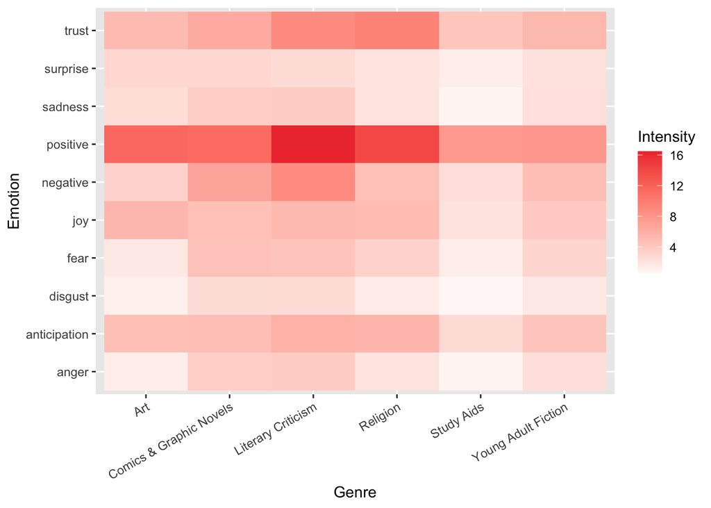

```r
#Creating heatmap to show the emotions

emotions_df <- df_sentiment %>%
  pivot_longer(cols = c("joy", "positive", "trust", "anticipation", "surprise", "sadness", "negative", "anger", "disgust", "fear"),
               names_to = "Emotion",
               values_to = "Intensity")

emotion_scores <- emotions_df %>%
  group_by(Genre, Emotion) %>%
  summarize(avg_intensity = mean(Intensity))
ggplot(emotion_scores, aes(x = Genre, y = Emotion, fill = avg_intensity)) +
  geom_tile() +
  scale_fill_gradient2(low = "dodgerblue", high = "brown2") +  # Adjust colors
  labs(x = "Genre", y = "Emotion", fill = "Intensity") +
  theme(axis.text.x = element_text(angle = 30, hjust=1))
```

From the above heatmap, “positive” emotion stands out as the highest intensity across all Genres, with “Sadness”, “Surprise” and “Disgust” recording lower intensities.

# TASK C

# Topic Modelling

In order to gain insights into customer segmentation and uncover hidden patterns, topic modelling techniques are applied to the review text feature to analyse clusters within the reviews.

# Data Exploration Analysis

```r
df_topic_m %>% group_by(Genre) %>% summarise(count=n()) %>% arrange(desc(count))->genre_counts
head(genre_counts) # Top 6 most reviewed genres
```

```
## # A tibble: 6 × 2
##   Genre                     count
##   <chr>                     <int>
## 1 Fiction                   12663
## 2 Religion                   4266
## 3 Juvenile Fiction           3190
## 4 Biography & Autobiography  3094
## 5 History                    3018
## 6 Business & Economics       2930
```

```r
summary(genre_counts) #Summary statistics showing Min. Max. and Average no. of reviews
```

```
##     Genre               count
##  Length:85          Min.   :    1.0
##  Class :character   1st Qu.:    8.0
##  Mode  :character   Median :  225.0
##                     Mean   :  697.6
##                     3rd Qu.:  741.0
##                     Max.   :12663.0
```

# Data Selection

Selecting the correct data is a pivotal step in topic modeling. Opting for a suitable dataset helps prevent encountering a model that drains resources, potentially taxing both computing resources and time.

The review_text feature serves as the primary source for identifying topics. The quantity of text chosen for analysis varies between 100 and 500 characters.

```r
df_topic_m <- df_topic_m %>%
  filter(str_count(Review_text) >= 100 & str_count(Review_text) <= 500)

set.seed(20)

# selecting genres that have more than 100 reviews.
greater_than_100 = filter(genre_counts,count >= 100)


#Ten indexes for selecting 10 genres
sample_index <- sample(length(unique(greater_than_100$Genre)), 10)
sampled_genre <- unique(greater_than_100$Genre)[sample_index]
df_topic_m <- df_topic_m %>% filter(Genre %in% sampled_genre)

print(sampled_genre)
```

```
##  [1] "Comics & Graphic Novels" "Study Aids"
##  [3] "Religion"                "Literary Criticism"
##  [5] "Young Adult Fiction"     "Art"
##  [7] "Games"                   "Drama"
##  [9] "Juvenile Fiction"        "Music"
```

```r
print(df_topic_m)
```

```
## # A tibble: 5,310 × 6
##    Title                     Rating Review_title Review_text Genre Review_id_new
##    <chr>                      <int> <chr>        <chr>       <chr>         <int>
##  1 The Secret of the Lord: …      5 great!       "Excellent… Reli…             4
##  2 Eldest (Inheritance, Boo…      5 A good book… "I've neve… Juve…             7
##  3 His Princess: Love Lette…      5 Im a daught… "This book… Reli…            15
##  4 Nausicaa of the Valley o…      5 Wonderful b… "... in a … Comi…            23
##  5 CliffsAP 5 Biology Pract…      5 Short and S… "These Pra… Stud…            43
##  6 Froggy Goes to Bed             5 Reality in … "My sister… Juve…            52
##  7 CliffsTestPrep Math Revi…      5 Great exerc… "Very usef… Stud…            57
##  8 Ghouls Gone Wild (Mostly…      5 My 11 year … "My 11 yea… Juve…            66
##  9 The ACLU vs. America: Ex…      5 ACLU vs Ame… "Every per… Reli…            88
## 10 Little Critter: Just a S…      5 mercer maye… "Mercer ma… Juve…           109
## # ℹ 5,300 more rows
```

10 genres were used for the analysis and a total observations of 5,310 were selected.

# Creating Term Document Matrix

```r
# Convert review text to corpus
corpus <- VCorpus(VectorSource(df_topic_m$Review_text))

# Creating additional stopwords
corpus <- tm_map(corpus, content_transformer(tolower)) %>%
  tm_map(content_transformer(function(x) gsub("[^a-zA-Z ]", "", x))) %>% tm_map(removeWords, stopwords("en")) %>%
  tm_map(stemDocument)

#Term document matrix
tdm <- TermDocumentMatrix(corpus, control = list(wordLengths = c(4, 15)))

tdm_matrix <- as.matrix(tdm)
```

# Word Distribution

Top 10 terms and their Frequencies

```r
term_frequencies <- rowSums(tdm_matrix)

# Create a data frame for plotting
term_frequency_df <- data.frame(term = names(term_frequencies), frequency = term_frequencies)

#Top 10 terms in descending order
top_terms <- term_frequency_df %>%
  arrange(desc(frequency)) %>%
  head(10)

print(top_terms)
```

```
##                term frequency
## book           book      7020
## read           read      2848
## great         great      1292
## love           love      1290
## stori         stori      1003
## good           good       877
## like           like       825
## will           will       819
## time           time       751
## recommend recommend       677
```

Histogram displaying term frequencies after stopwords were removed.

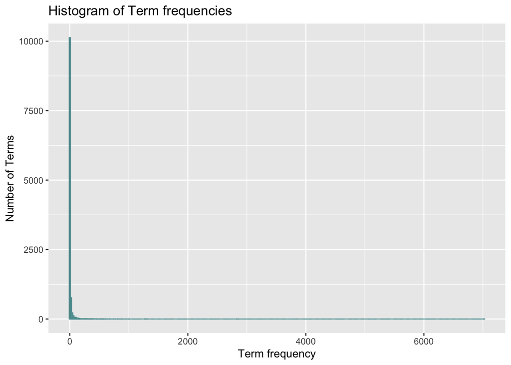

```r
# Create histogram
ggplot(term_frequency_df, aes(x = frequency)) +
  geom_histogram(binwidth = 20,color='cadetblue') +
  labs(title = "Histogram of Term frequencies",
       x = "Term frequency",
       y = "Number of Terms")+
  theme_gray()
```

# Filtering Words

Common and uncommon terms are eliminated from the dataset to avoid biasing or impacting document topics. Terms appearing in over 10% of the documents and those appearing in less than 5% of the documents are both removed.

```r
# Words that appear in more than 10% of the document
frequent_terms <- findFreqTerms(tdm, lowfreq = 0.10 * ncol(tdm_matrix))


# Terms that appear in less than 5% of documents
rare_terms <- findFreqTerms(tdm, highfreq = 0.05 * ncol(tdm_matrix))

print("Frequent Terms")
```

```
## [1] "Frequent Terms"
```

```r
print(frequent_terms)
```

```
##  [1] "book"      "good"      "great"     "help"      "just"      "like"
##  [7] "love"      "read"      "realli"    "recommend" "stori"     "time"
## [13] "want"      "well"      "will"      "year"
```

```r
print("First 20 Infrequent Terms")
```

```
## [1] "First 20 Infrequent Terms"
```

```r
print(rare_terms[1:20])
```

```
##  [1] "aaaachooo" "aagg"      "aamc"      "aaron"     "aayla"     "abandon"
##  [7] "abaut"     "abclearn"  "abdsit"    "abid"      "abil"      "abiut"
## [13] "abli"      "abomin"    "abort"     "abosilut"  "about"     "aboutread"
## [19] "abovegrad" "abraham"
```

# Useful Words

Most meaningful word that might be helpful for further analysis include: love

```r
# Retaining useful words
to_keep <- c("love")

to_remove <- frequent_terms[!frequent_terms %in% to_keep]

filtered_tdm_matrix <- tdm_matrix[!rownames(tdm_matrix) %in% to_remove, ]
filtered_tdm_matrix <- filtered_tdm_matrix[!rownames(filtered_tdm_matrix) %in% rare_terms, ]

# Calculate column sums
column_sums <- colSums(filtered_tdm_matrix)

# All zero columns
zero_columns <- which(column_sums == 0)

# Remove all zero columns or maintain original matrix
if(length(zero_columns) > 0) {
  filtered_tdm_matrix <- filtered_tdm_matrix[, -zero_columns]
} else {
  print("No zero columns in TDM matrix")
}
```

# Distribution

```r
term_frequencies <- rowSums(filtered_tdm_matrix)

# Data frame for plotting
term_frequency_df <- data.frame(term = names(term_frequencies), frequency = term_frequencies)

#Top 10 terms in descending order
top_terms <- term_frequency_df %>%
  arrange(desc(frequency)) %>%
  head(10)
print(top_terms)
```

```
##                  term frequency
## love             love      1290
## enjoy           enjoy       519
## make             make       505
## much             much       464
## mani             mani       463
## life             life       446
## look             look       440
## first           first       406
## understand understand       403
## wonder         wonder       397
```

Histogram displaying terms after removing non-relevants words for analysis.

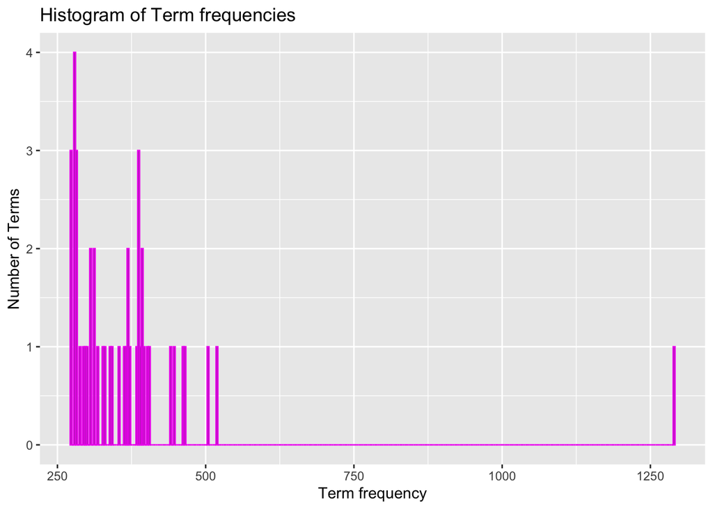

```r
# Create  histogram
ggplot(term_frequency_df, aes(x = frequency)) +
  geom_histogram(binwidth= 3,color='magenta2') +
  labs(title = "Histogram of Term frequencies",
       x = "Term frequency",
       y = "Number of Terms") +
  theme_gray()
```

```r
dtm <- t(filtered_tdm_matrix)
lda_model <- LDA(dtm, k = 6)
```

# LDA Visuals

Visualise Topics sorted by the model

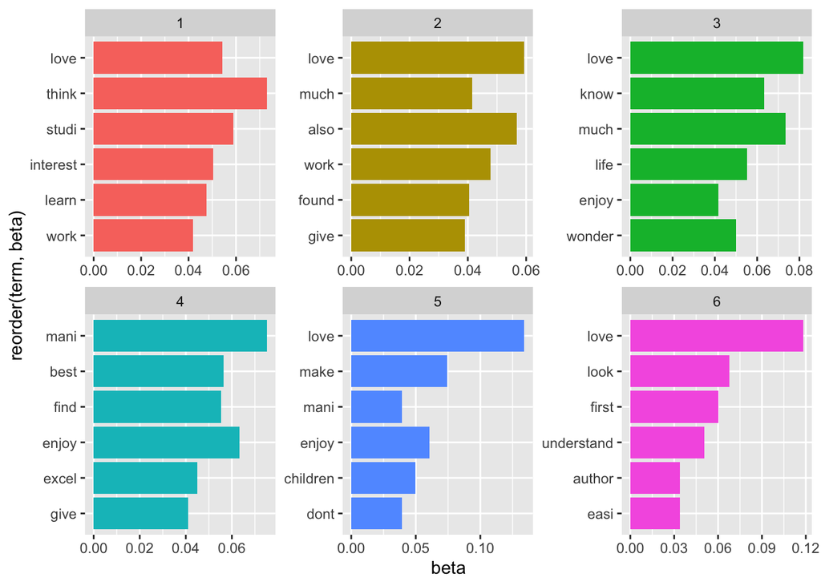

```r
# Probability of each word in a topic
topics <- tidy(lda_model, matrix = "beta")

#Top 6 terms with highest probability
top_terms <- topics %>%
  group_by(topic) %>%
  top_n(6, beta) %>%
  ungroup() %>%
  arrange(topic, -beta)

# Bar chart with the terms in each topic
top_terms %>%
  ggplot(aes(x = reorder(term, beta),
             y = beta, fill = factor(topic))) +
  geom_col(show.legend = FALSE) +
  facet_wrap(~ topic, scales = "free") +
  coord_flip()
```

Topic 1 - The keys terms from this shows how reviewers engaged with the contents they read.

Topic 2 - Reviewers were focused on discovering or grasping a broader theme of an information.

Topic 3 - This topic has key terms which encompasses affection and appreciation.

Topic 4 - Most words associated with topic suggest curiosity.

Topic 5 - Terms under this topic reflects on reviewers sense of achievement

Topic 6 - Key terms can be associated with a positive delightful gesture of first impressions made by reviewers.

# Perplexity Plot

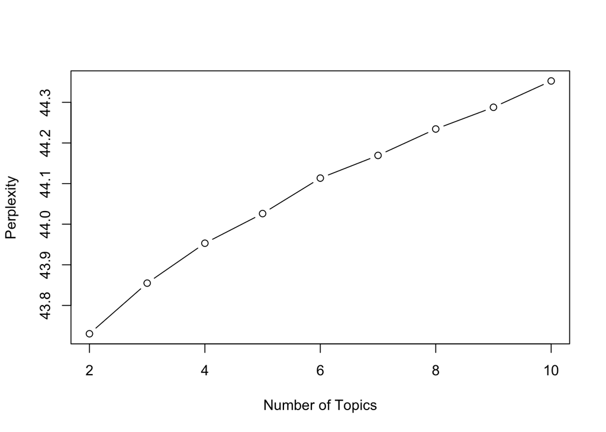

```r
range_k <- seq(2, 10, by = 1)
perplexities <- sapply(range_k, function(k) {
  model <- LDA(dtm, k = k, control = list(seed = 1))
  perplexity(model)
})

# Plotting perplexities
plot(range_k, perplexities, type = "b", xlab = "Number of Topics", ylab = "Perplexity")
```

# LDAvis

```r
set.seed(1)
lda_model <- LDA(dtm, k = 6)

lda_vis_data <- createJSON(phi = posterior(lda_model)$terms,
                          theta = posterior(lda_model)$topics,
                          doc.length = rowSums(as.matrix(dtm)),
                          vocab = colnames(as.matrix(dtm)),
                          term.frequency = colSums(as.matrix(dtm)))

serVis(lda_vis_data)
```

# Task D

# Using Support Vector Machine Model (SVM) for Classification.

Support vector machines (SVMs) are a widely used class of supervised machine learning models. Their learning algorithms analyse input data to generate representative training models that can classify new data points or predict target variables in regression tasks ( *GeeksforGeeks*,2023).

SVMs are highly effective at pattern recognition for classification problems, mapping inputs into multidimensional feature space and identifying boundaries between various output categories. Although SVMs may be applied to either classification or regression, their classification capabilities with both linear and non-linear separable data make them mostly utilised for disambiguating categorical outcomes.

# Data Selection for the SVM Model

```r
#Selecting the genres to use for prediction and using only 50 observations
filtered_labels <-
  head(df0 %>% filter(Genre==c("Biography & Autobiography","Religion")),50) %>% select(Title,Genre)

#Making Religion as class 1 and Biography & Autobiography as class 0
data_with_class <-
  filtered_labels %>% mutate(class = ifelse(Genre=='Biography & Autobiography',0,1))
data_with_class
```

```
## # A tibble: 50 × 3
##    Title                                                             Genre class
##    <chr>                                                             <chr> <dbl>
##  1 The Secret of the Lord: The Simple Key that Will Revive Your Spi… Reli…     1
##  2 Left to Tell: Discovering God Amidst The Rwandan Holocaust        Biog…     0
##  3 The Complete Idiot's Guide to the Bible, Third Edition            Reli…     1
##  4 Can You Cut It So It Looks Longer?: A Hairdresser's Memoirs       Biog…     0
##  5 The ACLU vs. America: Exposing the Agenda to Redefine Moral Valu… Reli…     1
##  6 Training for Transformation: A Handbook for Community Workers, V… Reli…     1
##  7 The Gospel of Mary of Magdala: Jesus and the First Woman Apostle  Reli…     1
##  8 The Cure D'Ars : St. Jean-Marie-Baptiste Vianney                  Biog…     0
##  9 Romans (Sacra Pagina) (Sacra Pagina Series)                       Reli…     1
## 10 Blue Like Jazz: Nonreligious Thoughts on Christian Spirituality   Biog…     0
## # ℹ 40 more rows
```

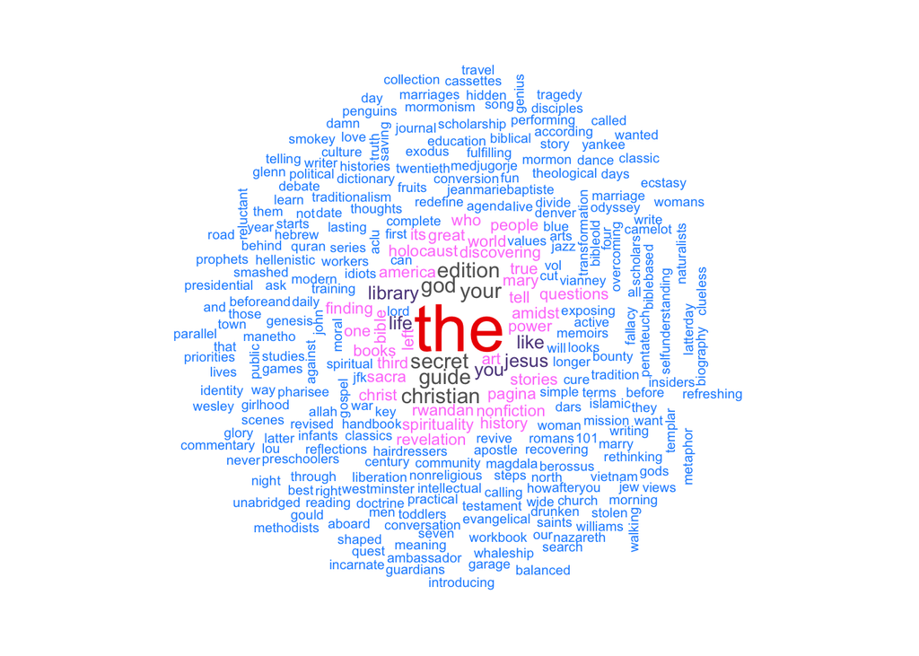

```r
wordcloud(words = data_with_class$Title, min.freq = 30,
          random.order=FALSE, random.color=FALSE,
          colors = sample(colors(), size = 20),scale=c(3,0.5))
```

# Using SVM Model to predict the Genre of a book

```r
# Sample text data
text_data <- data_with_class$Title

# Corresponding class labels
Genre <- data_with_class$class

# Convert text data to a data frame
data <- data.frame(text = text_data, Genre = Genre)

# Create a document-term matrix
corpus <- Corpus(VectorSource(data$text))
dtm <- DocumentTermMatrix(corpus)

# Convert to a matrix
dtm_matrix <- as.matrix(dtm)

# Perform text classification using Support Vector Machines (SVM)

svm_model <- svm(dtm_matrix, data$Genre)

# Sample test data
test_data <- "The Secret of the Lord: The Simple Key that Will Revive Your Spiritual Power"

# Create a document-term matrix for test data
test_corpus <- Corpus(VectorSource(test_data))
test_dtm <- DocumentTermMatrix(test_corpus, control = list(dictionary = Terms(dtm)))

# Convert to a matrix
test_dtm_matrix <- as.matrix(test_dtm)

# Predict the class labels for test data
predictions <- predict(svm_model, test_dtm_matrix)

# Display the predictions
print("Predictions:")
```

```
## [1] "Predictions:"
```

```r
print(predictions)
```

```
##         1
## 0.9500759
```

From the above outcome,SVM model was used to predict a Genre based on a given book Title.

In future works, if more book titles are trained with the model, a prediction of the Genre of any book can be predicted closer to 100% by the SVM model.

# REFERENCES

*GeeksforGeeks* (2023) Available at: https://www.geeksforgeeks.org/classifying-data-using-support-vector-machinessvms-in-r/ (Accessed: 10 February 2024).